# assignment

Marco Fiorani Borraccino

2026-04-29

```r
suppressPackageStartupMessages({
  library(epiwraps)
  library(ggplot2)
  library(AnnotationHub)
  library(ensembldb)
  library(edgeR)
  library(rtracklayer)
  library(BiocParallel)
  library(bsseq)   # Class and tools to analyze bisulfite sequencing data at CpG-level
  library(DMRcate) # Identification of differentially-methylated regions
  library(dplyr)
  library(ggplot2)
})
```

## Download data

```r
bs <- readRDS("ESC_astrocytes_BSseq.rds")
genes <- readRDS("hg19_chr1_genes.rds")

# remove CpGs that have 0 coverage in some samples
bs <- bs[rowSums(assay(bs, "Cov") > 0) == ncol(bs), ]

# define the experimental design
design <- model.matrix(~celltype, data=pData(bs))
methdesign <- modelMatrixMeth(design)

# smooth the data (Required for DMRcate) - betas at single CpG level
bs <- BSmooth(bs, BPPARAM=MulticoreParam(2, progress=TRUE))
```

[output not shown]

## Task 1

```r
# Statistical Testing
#Is the methylation level here significantly different in Astrocytes compared to ESCs, and is there enough raw coverage to trust that difference? (using beta data from smooth but raw count)
#Single CpG with ∆beta (e.g., +20% or -40%) with p-value
seqAnnot <- sequencing.annotate(bs, methdesign, all.cov=TRUE, coef="celltypeastrocytes")
```

```
## Filtering out all CpGs where at least one sample has zero coverage...
```

```
## Processing BSseq object...
```

```
## Transforming counts...
```

```
## Fitting model...
```

```
## Your contrast returned 45364 individually significant CpGs. We recommend the default setting of pcutoff in dmrcate().
```

```r
# Region Finder
dmrcateRes <- dmrcate(seqAnnot, C=2, min.cpgs=5)
```

```
## Fitting chr1...
```

```
## Fitting chr10...
```

```
## Fitting chr11...
```

```
## Fitting chr12...
```

```
## Fitting chr13...
```

```
## Fitting chr14...
```

```
## Fitting chr15...
```

```
## Fitting chr16...
```

```
## Fitting chr17...
```

```
## Fitting chr18...
```

```
## Fitting chr19...
```

```
## Fitting chr2...
```

```
## Fitting chr20...
```

```
## Fitting chr21...
```

```
## Fitting chr22...
```

```
## Fitting chr3...
```

```
## Fitting chr4...
```

```
## Fitting chr5...
```

```
## Fitting chr6...
```

```
## Fitting chr7...
```

```
## Fitting chr8...
```

```
## Fitting chr9...
```

```
## Fitting chrM...
```

```
## Fitting chrX...
```

```
## Fitting chrY...
```

```
## Demarcating regions...
```

```
## Done!
```

```r
#dmrcateRes <- dmrcate(seqAnnot, C=10, min.cpgs=5) #(Higher-resolution but increase in absolute false positive)
#dmrcateRes <- dmrRanges[dmrRanges$HMFDR < 0.001 & abs(dmrRanges$meandiff) > 0.20] #Filter to restore less false positive
dmrRanges <- extractRanges(dmrcateRes, genome="hg19")
```

```
## see ?DMRcatedata and browseVignettes('DMRcatedata') for documentation
```

```
## loading from cache
```

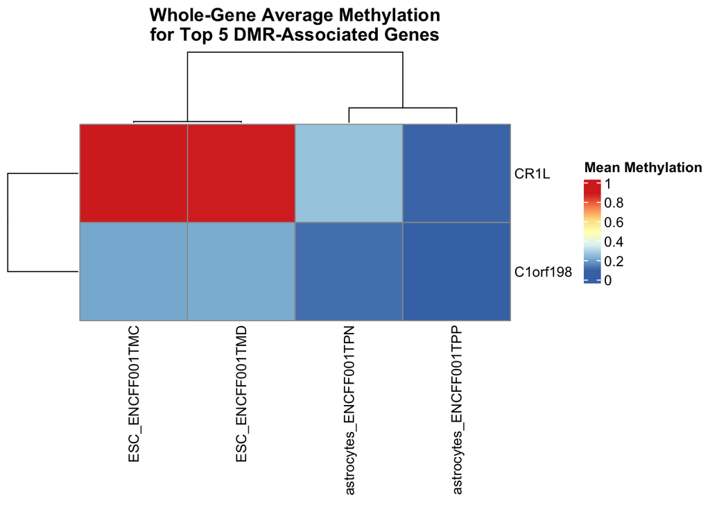

```r
# identify top 5 DMR on chr1
dmr_chr1 <- dmrRanges[seqnames(dmrRanges) == "chr1"]
top5_dmrs <- head(dmr_chr1[order(abs(dmr_chr1$meandiff), decreasing=TRUE)], 5)

# genes found in top 5 DMR regions
genes_in_top5 <- subsetByOverlaps(genes, top5_dmrs)


#Plotting

# --- FIRST PLOT: Gene Body Average (Diluted) ---
# Extract average methylation in the gene
# methylation in genes is diluted by the lenght of the genes itself
met_genes <- bsseq::getMeth(bs, regions=genes_in_top5, what="perRegion")
rownames(met_genes) <- genes_in_top5$symbol
pheatmap(met_genes, main="Whole-Gene Average Methylation\nfor Top 5 DMR-Associated Genes", name="Mean Methylation")
```

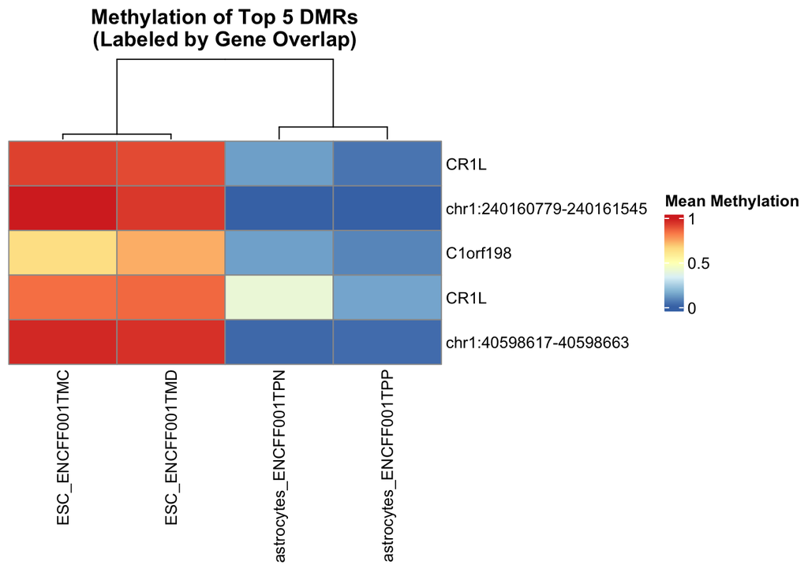

```r
# --- SECOND PLOT: DMR Window Average (Undiluted) ---
# Extract average methylation in the DMR regions (not the whole gene)
met_dmr_only <- bsseq::getMeth(bs, regions=top5_dmrs, what="perRegion")

# default labels (coordinates) for all 5 top DMR
dmr_coords <- paste0(seqnames(top5_dmrs), ":", start(top5_dmrs), "-", end(top5_dmrs))
hits <- findOverlaps(top5_dmrs, genes)
dmr_coords[queryHits(hits)] <- genes$symbol[subjectHits(hits)]
rownames(met_dmr_only) <- dmr_coords
pheatmap(met_dmr_only,main="Methylation of Top 5 DMRs\n(Labeled by Gene Overlap)",  name="Mean Methylation", cluster_rows = FALSE)
```

#### While the first plot shows whole-gene methylation averages that are diluted by the inclusion of non-DMR sequences, the second plot highlights the undiluted signal by focusing strictly on the high-precision DMR windows.

#### Analysis shows that only 3 out of the 5 top DMRs physically overlap with gene bodies. Furthermore, two of these top DMRs are situated within the same gene (CR1L).

## Task 2

```r
# loading data
ATAC_AstroVsESC<- readRDS("ATAC_AstroVsESC_subset.rds")
```

#### Two different methods based on two different assumptions:

#### 1. Change in methylation in locus A can influence change in ATAC in locus B nearby

#### 2. Change in methylation in locus A can influence change in ATAC in locus A

### Method 1 (Change in methylation in locus A can influence change in ATAC in locus B nearby) - p/FDR = 0.001

```r
# --- Method 1 (for nearby regions correlation) ---

# find overlapping regions between DMRs and ATAC peaks
hits_overlaps_DMRvsATAC <- findOverlaps(dmrRanges, ATAC_AstroVsESC)
head(hits_overlaps_DMRvsATAC, 5)
```

```
## Hits object with 5 hits and 0 metadata columns:
##       queryHits subjectHits
##       <integer>   <integer>
##   [1]         1        1505
##   [2]         1        2041
##   [3]         1        2860
##   [4]         1        2983
##   [5]         1        3176
##   -------
##   queryLength: 2580 / subjectLength: 5279
```

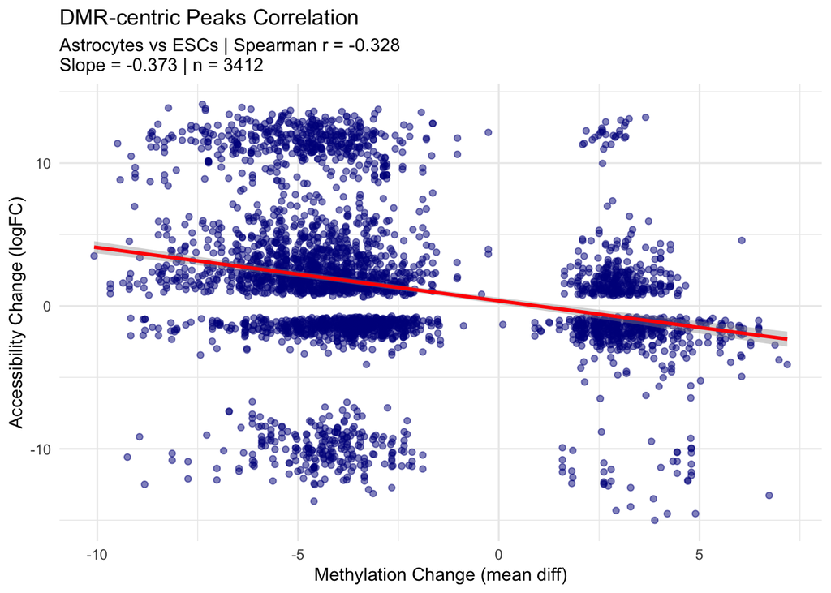

```r
# meandiff: Change in methylation (Positive = Hypermethylated in Astrocytes)
# logFC: Change in accessibility (Positive = More accessible in Astrocytes)
df_comp <- data.frame(
  meth_diff = dmrRanges$meandiff[queryHits(hits_overlaps_DMRvsATAC)],
  meth_fdr  = dmrRanges$min_smoothed_fdr[queryHits(hits_overlaps_DMRvsATAC)],
  atac_diff = ATAC_AstroVsESC$logFC[subjectHits(hits_overlaps_DMRvsATAC)],
  atac_fdr  = ATAC_AstroVsESC$FDR[subjectHits(hits_overlaps_DMRvsATAC)]
)
#Filter by significance
df_comp <- subset(df_comp, meth_fdr < 0.001 & atac_fdr < 0.001)

# --- Correlation ---
# Correlation Coefficient Spearman
cor_spearman <- cor(df_comp$meth_diff, df_comp$atac_diff, method = "spearman")
# Slope
fit <- lm(atac_diff ~ meth_diff, data = df_comp)
slope <- coef(fit)["meth_diff"]

# Scatter plot of differences
ggplot(df_comp, aes(x = meth_diff, y = atac_diff)) +
  geom_point(alpha = 0.5, color = "darkblue") +
  geom_smooth(method = "lm", color = "red") +
  labs(
    title = "DMR-centric Peaks Correlation",
    x = "Methylation Change (mean diff)",
    y = "Accessibility Change (logFC)",
    subtitle = paste0("Astrocytes vs ESCs | Spearman r = ", round(cor_spearman, 3),
                      "\nSlope = ", round(slope, 3), " | n = ", nrow(df_comp))
  ) +
  theme_minimal()
```

### Method 2 (Change in methylation in locus A can influence change in ATAC in the same locus A) - p/FDR = 0.001

```r
# --- Method 2 (for same loci correlations) ---
# Filter only only CpGs in ATAC peaks
bs_targeted <- subsetByOverlaps(bs, ATAC_AstroVsESC)

# Run the statistical tests over them to see which peaks contain a DMR
seqAnnot_targeted <- sequencing.annotate(bs_targeted, methdesign, all.cov = TRUE, coef = "celltypeastrocytes")
```

```
## Filtering out all CpGs where at least one sample has zero coverage...
```

```
## Processing BSseq object...
```

```
## Transforming counts...
```

```
## Fitting model...
```

```
## Your contrast returned 26624 individually significant CpGs. We recommend the default setting of pcutoff in dmrcate().
```

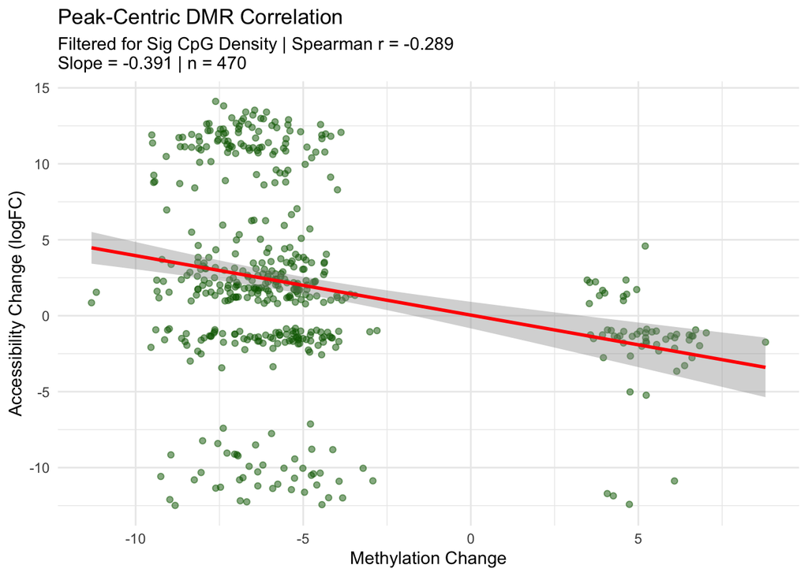

```r
cpg_ranges <- seqAnnot_targeted@ranges

# map CpG results to ATAC Peaks
cpg_hits <- findOverlaps(cpg_ranges, ATAC_AstroVsESC)

# Manual Aggregation (One Peak = One DMR)
df_peak_dmr <- data.frame(
    peak_id = subjectHits(cpg_hits),
    cpg_p   = mcols(cpg_ranges)$rawpval[queryHits(cpg_hits)],
    cpg_diff = mcols(cpg_ranges)$diff[queryHits(cpg_hits)]
) %>%
    group_by(peak_id) %>%
    summarise(
        # Total CpGs in peak
        n_total = n(),
        # Count of SIGNIFICANT CpGs (p < 0.001)
        n_sig = sum(cpg_p < 0.001, na.rm = TRUE),
        # Average methylation change across all CpGs in the peak
        mean_meth_diff = mean(cpg_diff, na.rm = TRUE),
        # Combine p-values using Stouffer's method
        combined_p = {
            # Handle edge cases with very small p-values
            z_scores <- qnorm(1 - pmax(cpg_p, 1e-15) / 2)
            2 * (1 - pnorm(abs(sum(z_scores) / sqrt(n()))))
        }
    )

#print(head(df_peak_dmr,5)) debug

# Filter peaks with DMR inside
# Rule: At least 5 SIGNIFICANT CpGs per 300bp of peaks
atac_info <- data.frame(
    peak_id = 1:length(ATAC_AstroVsESC),
    peak_width = width(ATAC_AstroVsESC),
    atac_logFC = ATAC_AstroVsESC$logFC,
    atac_fdr = ATAC_AstroVsESC$FDR
)

df_final <- df_peak_dmr %>%
    inner_join(atac_info, by = "peak_id") %>%
    mutate(n_sig_required = ceiling((peak_width / 300) * 5)) %>%
    # FILTER: Must meet significant CpG density
    dplyr::filter(n_sig >= n_sig_required) %>%
    # FILTER: ATAC peak must be significant
    dplyr::filter(atac_fdr < 0.001)

# Assign FDR to the Methylation Signal
df_final$combined_meth_fdr <- p.adjust(df_final$combined_p, method = "fdr")

# Final Filter for significant Methylation FDR < 0.001
df_final_sig <- df_final %>% dplyr::filter(combined_meth_fdr < 0.001)
#print(head(df_final_sig,5)) debug

# --- Correlation ---
# Correlation Coefficient Spearman
correlation_val <- cor(df_final_sig$mean_meth_diff, df_final_sig$atac_logFC, method = "spearman")
#Slope
fit <- lm(atac_logFC ~ mean_meth_diff, data = df_final_sig)
slope <- coef(fit)["mean_meth_diff"]

#plot
ggplot(df_final_sig, aes(x = mean_meth_diff, y = atac_logFC)) +
    geom_point(alpha = 0.5, color = "darkgreen") +
    geom_smooth(method = "lm", color = "red") +
    labs(
        title = "Peak-Centric DMR Correlation",
        subtitle = paste0("Filtered for Sig CpG Density | Spearman r = ", round(correlation_val, 3),
                      "\nSlope = ", round(slope, 3), " | n = ", nrow(df_final_sig)),
        x = "Methylation Change",
        y = "Accessibility Change (logFC)"
    ) +
    theme_minimal()
```

#### Method 1 assumes that regulatory crosstalk occurs within a broader genomic neighborhood, where a Differentially Methylated Region (DMR) might influence accessibility at nearby ATAC-seq peaks.

#### Method 2, conversely, assumes a strictly local coupling where only the methylation status physically inside the open chromatin site governs its accessibility.

#### Biologically, Method 2 provides higher spatial precision by filtering out “bystander” CpGs in flanking regions and focusing solely on the regulatory core. While both methods yield similar Spearman correlation coefficients (-0.32 and -0.29 respectively), proving the overall direction and consistency of the relationship are biologically stable, Method 2 results in a steeper slope.

#### These plots reveals a consistent inverse relationship (slope = -0.39) where localized methylation within the regulatory core acts as a significant, albeit partial (Spearman r = -0.29), driver of decreased chromatin accessibility